# Tidyverse carpentry - day 1, afternoon

Desiree Treichler

6 juni 2017

Preparations: load data

```r
library(tidyverse)
gapminder <- read_csv("../Data/gapminder-FiveYearData.csv")
```

# The pipe: %>%

We could write

```r
rep("This is an example", times=3)
```

```
## [1] "This is an example" "This is an example" "This is an example"
```

or, do the same with a pipe:

```r
"This is an example" %>% rep(times=3)
```

```
## [1] "This is an example" "This is an example" "This is an example"
```

## Make a new dataframe and show the head

```r
year_country_gdp <- select(gapminder,year,country,gdpPercap)
head(year_country_gdp)
```

```
## # A tibble: 6 x 3
##    year     country gdpPercap
##   <int>       <chr>     <dbl>
## 1  1952 Afghanistan  779.4453
## 2  1957 Afghanistan  820.8530
## 3  1962 Afghanistan  853.1007
## 4  1967 Afghanistan  836.1971
## 5  1972 Afghanistan  739.9811
## 6  1977 Afghanistan  786.1134
```

– or, do the same with a pipe:

```r
year_country_gdp <- gapminder %>%
  select(year,country, gdpPercap)
head(year_country_gdp)
```

```
## # A tibble: 6 x 3
##    year     country gdpPercap
##   <int>       <chr>     <dbl>
## 1  1952 Afghanistan  779.4453
## 2  1957 Afghanistan  820.8530
## 3  1962 Afghanistan  853.1007
## 4  1967 Afghanistan  836.1971
## 5  1972 Afghanistan  739.9811
## 6  1977 Afghanistan  786.1134
```

We can also do a filter and plot directly.

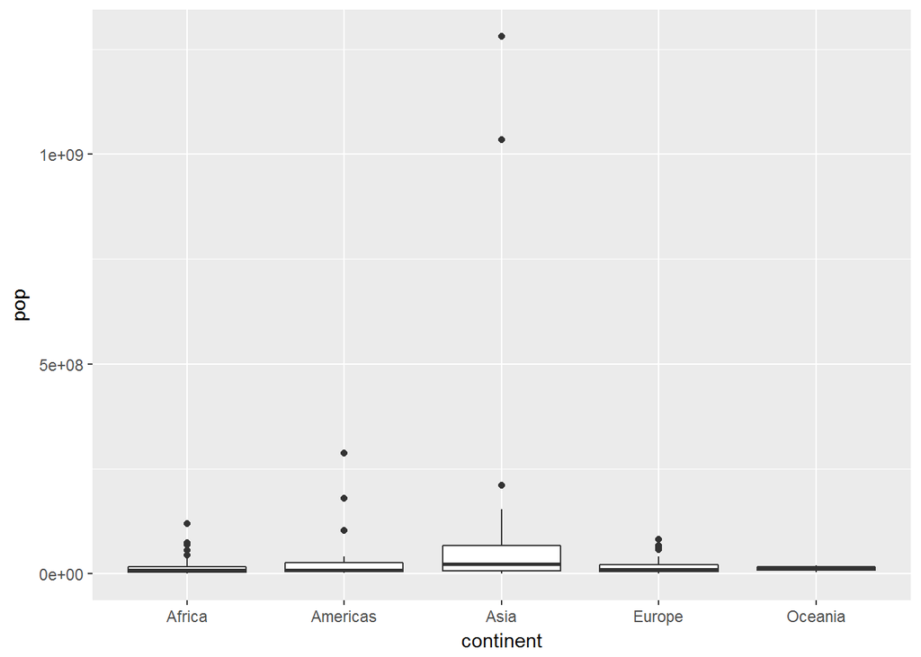

```r
gapminder %>% filter(year==2002) %>%
  ggplot(mapping=aes(x=continent, y=pop)) +
  geom_boxplot()
```

Or filter and select in the same command.

```r
year_country_gdp_euro <- gapminder %>%
  filter(continent=="Europe") %>%
  select(year,country,gdpPercap)
head(year_country_gdp_euro)
```

```
## # A tibble: 6 x 3
##    year country gdpPercap
##   <int>   <chr>     <dbl>
## 1  1952 Albania  1601.056
## 2  1957 Albania  1942.284
## 3  1962 Albania  2312.889
## 4  1967 Albania  2760.197
## 5  1972 Albania  3313.422
## 6  1977 Albania  3533.004
```

**Challenge 1: A single command that produces a data frame that has the Norwegian values for gdpPercap, liofeExp and year. How many rows does your data frame have and why?**

```r
Norway <- gapminder %>%
  filter(country=="Norway") %>%
  select(gdpPercap, lifeExp, year)
Norway
```

```
## # A tibble: 12 x 3
##    gdpPercap lifeExp  year
##        <dbl>   <dbl> <int>
##  1  10095.42  72.670  1952
##  2  11653.97  73.440  1957
##  3  13450.40  73.470  1962
##  4  16361.88  74.080  1967
##  5  18965.06  74.340  1972
##  6  23311.35  75.370  1977
##  7  26298.64  75.970  1982
##  8  31540.97  75.890  1987
##  9  33965.66  77.320  1992
## 10  41283.16  78.320  1997
## 11  44683.98  79.050  2002
## 12  49357.19  80.196  2007
```

Answer: the dataset has twelve rows.

## Grouping

Take the gapminder dataset, group it by continent, and summarize per group.

```r
gapminder %>%
  group_by(continent) %>%
  summarize(mean_gdpPercap=mean(gdpPercap))
```

```
## # A tibble: 5 x 2
##   continent mean_gdpPercap
##       <chr>          <dbl>
## 1    Africa       2193.755
## 2  Americas       7136.110
## 3      Asia       7902.150
## 4    Europe      14469.476
## 5   Oceania      18621.609
```

Add some plotting to the pipe.

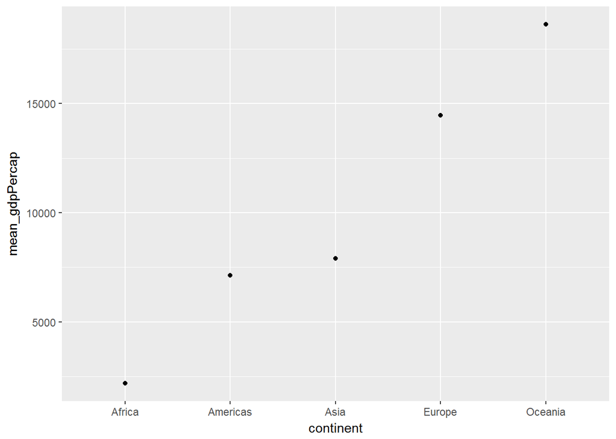

```r
gapminder %>%
  group_by(continent) %>%
  summarize(mean_gdpPercap=mean(gdpPercap)) %>%
  ggplot(mapping = aes(x=continent, y = mean_gdpPercap))+
  geom_point()
```

**Challenge 2: Calculate the average life expectancy per country in Asia. Which one has the longest onem which one the shortest?**

```r
gapminder %>%
  filter(continent=="Asia") %>%
  group_by(country) %>%
  summarize(mean_lifeExp = mean(lifeExp)) %>%
  filter(mean_lifeExp==min(mean_lifeExp)|mean_lifeExp==max(mean_lifeExp))
```

```
## # A tibble: 2 x 2
##       country mean_lifeExp
##         <chr>        <dbl>
## 1 Afghanistan     37.47883
## 2       Japan     74.82692
```

The last filter acts as a selector, and choses only the min/max value.

Alternatively, use arrange to order the list:

```r
gapminder %>%
  filter(continent=="Asia") %>%
  group_by(country) %>%
  summarize(mean_lifeExp = mean(lifeExp)) %>%
  arrange(mean_lifeExp)
```

```
## # A tibble: 33 x 2
##        country mean_lifeExp
##          <chr>        <dbl>
##  1 Afghanistan     37.47883
##  2  Yemen Rep.     46.78042
##  3    Cambodia     47.90275
##  4       Nepal     48.98633
##  5  Bangladesh     49.83408
##  6       India     53.16608
##  7     Myanmar     53.32167
##  8   Indonesia     54.33575
##  9    Pakistan     54.88225
## 10    Mongolia     55.89033
## # ... with 23 more rows
```

Or, we could solve this graphically:

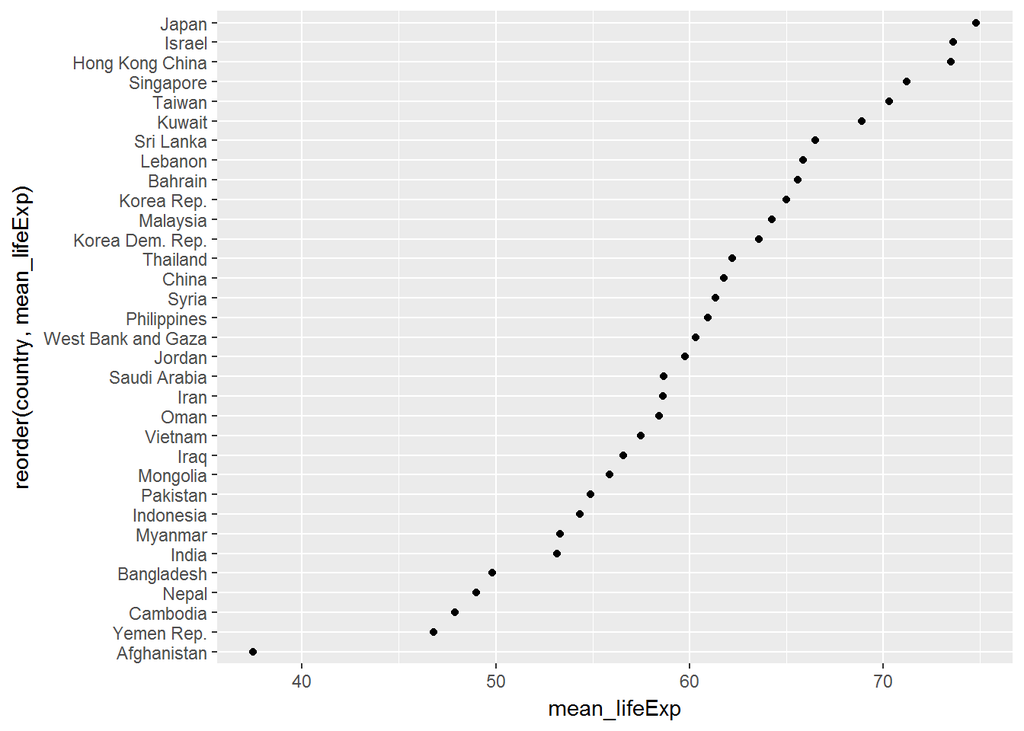

```r
gapminder %>%
  filter(continent=="Asia") %>%
  group_by(country) %>%
  summarize(mean_lifeExp = mean(lifeExp)) %>%
  ggplot(mapping = aes(x=reorder(country,mean_lifeExp), y = mean_lifeExp))+ geom_point() +
  coord_flip()
```

To sort the y axis, specify the sorting variable directly in the aes() function.

## Mutate

Mutate adds new variables and preserves existing; transmute drops existing variables. Do some mutating and pipe the result directly to the head function:

```r
gapminder %>%
  mutate(gdp_billion=gdpPercap*pop/10^9) %>%
  head()
```

```
## # A tibble: 6 x 7
##       country  year      pop continent lifeExp gdpPercap gdp_billion
##         <chr> <int>    <dbl>     <chr>   <dbl>     <dbl>       <dbl>
## 1 Afghanistan  1952  8425333      Asia  28.801  779.4453    6.567086
## 2 Afghanistan  1957  9240934      Asia  30.332  820.8530    7.585449
## 3 Afghanistan  1962 10267083      Asia  31.997  853.1007    8.758856
## 4 Afghanistan  1967 11537966      Asia  34.020  836.1971    9.648014
## 5 Afghanistan  1972 13079460      Asia  36.088  739.9811    9.678553
## 6 Afghanistan  1977 14880372      Asia  38.438  786.1134   11.697659
```

This shows the GDP in billions for every country and every year.

We can also summarize this further, and group by continent/year.

```r
gapminder %>%
  mutate(gdp_billion=gdpPercap*pop/10^9) %>%
group_by(continent,year) %>%
  summarize(mean_gdp_billion=mean(gdp_billion))
```

```
## Source: local data frame [60 x 3]
## Groups: continent [?]
##
## # A tibble: 60 x 3
##    continent  year mean_gdp_billion
##        <chr> <int>            <dbl>
##  1    Africa  1952         5.992295
##  2    Africa  1957         7.359189
##  3    Africa  1962         8.784877
##  4    Africa  1967        11.443994
##  5    Africa  1972        15.072242
##  6    Africa  1977        18.694899
##  7    Africa  1982        22.040401
##  8    Africa  1987        24.107264
##  9    Africa  1992        26.256978
## 10    Africa  1997        30.023174
## # ... with 50 more rows
```

We can create a summary dataset for each country to use later.

```r
gapminder_country_summary <-
  gapminder %>%
  group_by(country) %>%
  summarize(mean_lifeExp = mean(na.omit(lifeExp))) %>% #na.omit would remove NaNs, if there are any
  arrange(mean_lifeExp)
```

## Maps

Now, let’s add some maps! First, load the package.

```r
library(maps)
```

Then, get some coordinates for the entire world.

```r
map_data("world") %>%
  head()
```

```
##        long      lat group order region subregion
## 1 -69.89912 12.45200     1     1  Aruba      <NA>
## 2 -69.89571 12.42300     1     2  Aruba      <NA>
## 3 -69.94219 12.43853     1     3  Aruba      <NA>
## 4 -70.00415 12.50049     1     4  Aruba      <NA>
## 5 -70.06612 12.54697     1     5  Aruba      <NA>
## 6 -70.05088 12.59707     1     6  Aruba      <NA>
```

## rename and left join

Unfortunately, in this dataset, the countries are called “region”. Rename this, join it with the country summary gapminder dataset, and send it directly to the plot.

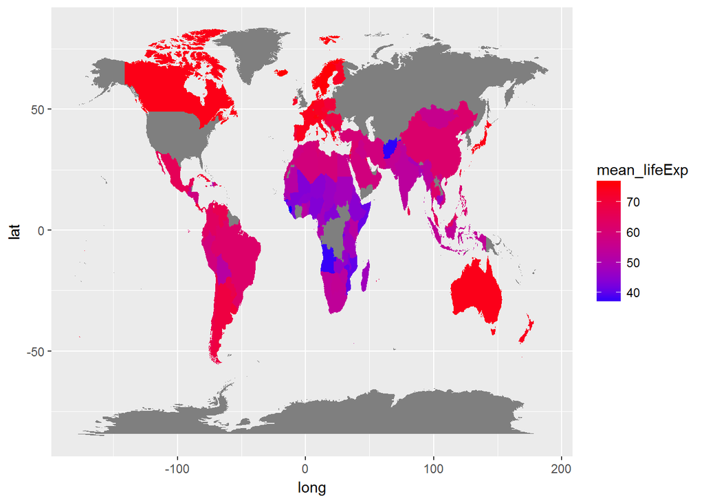

```r
map_data("world") %>%
  rename(country=region) %>%
  left_join(gapminder_country_summary, by="country") %>%
  ggplot() + geom_polygon(aes(x=long, y=lat, group=group, fill=mean_lifeExp)) +
  scale_fill_gradient(low="blue", high="red") # what colours to use
```

The holes are where the gapminder country named don’t match the names of the map_data region names.